# Exploring the Synthetic Long-Timeframe Transaction Dataset

Author

Mick Cooney mickcooney@gmail.com

Published

February 16, 2024

This workbook was created using the ‘dataexpks’ template:

https://github.com/DublinLearningGroup/dataexpks

# 1 Introduction

This workbook performs the basic data exploration of the dataset.

```r
dataexp_level_exclusion_threshold <- 100

dataexp_cat_level_count <- 60
dataexp_hist_bins_count <- 50
```

# 2 Load Data

First we load the dataset.

```r
### Data is loaded into dataset rawdata_tbl here
rawdata_tbl <- read_rds("data/rawsynthdata_longframe_transactions_tbl.rds")

glimpse(rawdata_tbl)
```

```
Rows: 43,153
Columns: 4
$ customer_id   <chr> "LFC201001_0001", "LFC201001_0003", "LFC201001_0002", "L…
$ tnx_timestamp <dttm> 2010-01-01 04:21:16, 2010-01-03 09:17:44, 2010-01-03 11…
$ invoice_id    <chr> "T20100101-0001", "T20100103-0001", "T20100103-0002", "T…
$ tnx_amount    <dbl> 82.97, 174.89, 126.14, 121.05, 99.23, 238.19, 54.69, 116…
```

## 2.1 Perform Quick Data Cleaning

```r
### _TEMPLATE_
### Do simple datatype transforms and save output in data_tbl
data_tbl <- rawdata_tbl %>% set_colnames(names(.) |> to_snake_case())

glimpse(data_tbl)
```

```
Rows: 43,153
Columns: 4
$ customer_id   <chr> "LFC201001_0001", "LFC201001_0003", "LFC201001_0002", "L…
$ tnx_timestamp <dttm> 2010-01-01 04:21:16, 2010-01-03 09:17:44, 2010-01-03 11…
$ invoice_id    <chr> "T20100101-0001", "T20100103-0001", "T20100103-0002", "T…
$ tnx_amount    <dbl> 82.97, 174.89, 126.14, 121.05, 99.23, 238.19, 54.69, 116…
```

## 2.2 Create Derived Variables

We now create derived features useful for modelling. These values are new variables calculated from existing variables in the data.

```r
dow_order   <- c("Mon", "Tue", "Wed", "Thu", "Fri", "Sat", "Sun")
month_order <- c(
  "Jan", "Feb", "Mar", "Apr", "May", "Jun", "Jul", "Aug", "Sep", "Oct",
  "Nov", "Dec"
  )

data_tbl <- data_tbl |>
  mutate(
    tnx_dow   = format(tnx_timestamp, "%a") |> fct_relevel(dow_order),
    tnx_month = format(tnx_timestamp, "%b") |> fct_relevel(month_order),
    tnx_week  = format(tnx_timestamp, "%W"),

    .after = tnx_timestamp
    )

data_tbl |> glimpse()
```

```
Rows: 43,153
Columns: 7
$ customer_id   <chr> "LFC201001_0001", "LFC201001_0003", "LFC201001_0002", "L…
$ tnx_timestamp <dttm> 2010-01-01 04:21:16, 2010-01-03 09:17:44, 2010-01-03 11…
$ tnx_dow       <fct> Fri, Sun, Sun, Tue, Wed, Wed, Fri, Sat, Sun, Mon, Tue, T…
$ tnx_month     <fct> Jan, Jan, Jan, Jan, Jan, Jan, Jan, Jan, Jan, Jan, Jan, J…
$ tnx_week      <chr> "00", "00", "00", "01", "01", "01", "01", "01", "01", "0…
$ invoice_id    <chr> "T20100101-0001", "T20100103-0001", "T20100103-0002", "T…
$ tnx_amount    <dbl> 82.97, 174.89, 126.14, 121.05, 99.23, 238.19, 54.69, 116…
```

# 3 Perform Basic Checks on Data

We now want to look at some very high level checks on the data, and we leverage some of the functionality provided by `DataExplorer`.

## 3.1 Create High-Level Visualisations

We first want to look at a visualisation of some high-level summarys of the meta-data on this dataset. This gives us a quick view of the categorical and 1numeric values in the dataset, as well as the proportions of missing values.

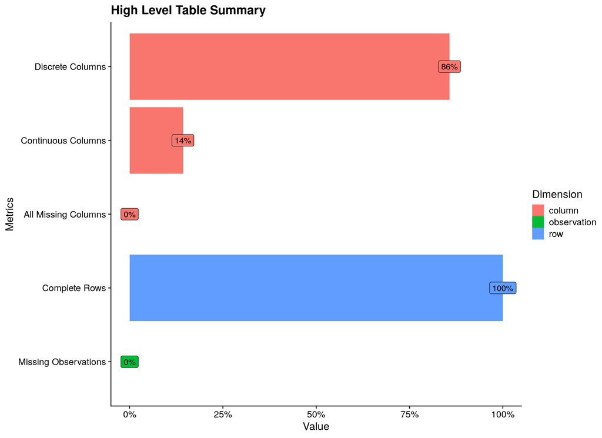

```r
data_tbl |>
  plot_intro(
    title   = "High Level Table Summary",
    ggtheme = theme_cowplot()
    )
```

## 3.2 Check Missing Values

Before we do anything with the data, we first check for missing values in the dataset. In some cases, missing data is coded by a special character rather than as a blank, so we first correct for this.

```r
### _TEMPLATE_
### ADD CODE TO CORRECT FOR DATA ENCODING HERE
```

With missing data properly encoded, we now visualise the missing data in a number of different ways.

### 3.2.1 Univariate Missing Data

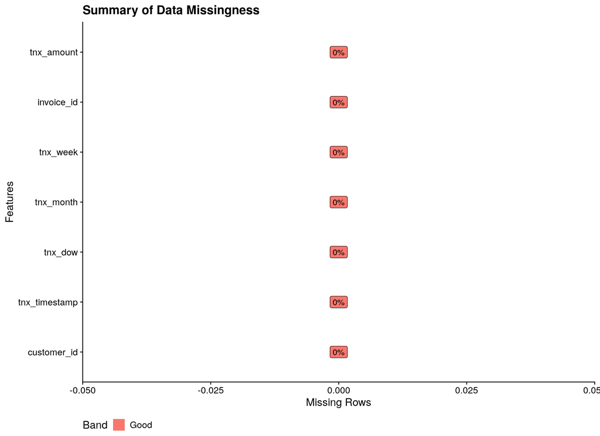

```r
data_tbl |>
  plot_missing(
    title   = "Summary of Data Missingness",
    group   = list(Good = 0.05, Acceptable = 0.2, Bad = 0.8, Remove = 1),
    ggtheme = theme_cowplot()
    )
```

We now want to repeat this plot but only for those columns that have some missing values.

[figure not shown]

```r
data_tbl |>
  plot_missing(
    title        = "Summary of Data Missingness (missing variables only)",
    missing_only = TRUE,
    group        = list(Good = 0.05, Acceptable = 0.2, Bad = 0.8, Remove = 1),
    ggtheme      = theme_cowplot()
    )
```

### 3.2.2 Multivariate Missing Data

It is useful to get an idea of what combinations of variables tend to have variables with missing values simultaneously, so to construct a visualisation for this we create a count of all the times given combinations of variables have missing values, producing a heat map for these combination counts.

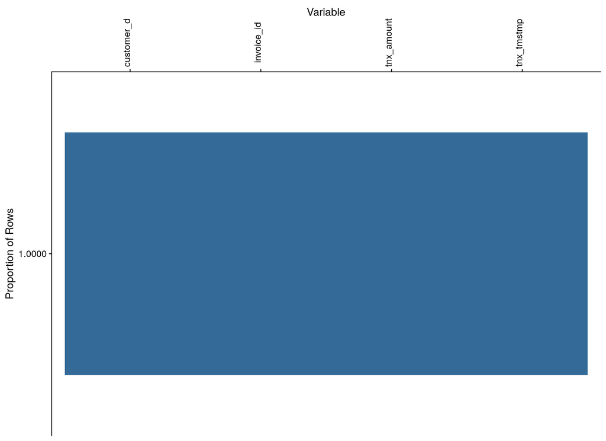

```r
dataexp_missing_group_count <- 20

row_count <- rawdata_tbl |> nrow()

count_nas <- ~ .x |> are_na() |> vec_cast(integer())

missing_vizdata_tbl <- rawdata_tbl |>
  mutate(across(everything(), count_nas)) %>%
  mutate(label = pmap_chr(., str_c)) |>
  group_by(label) |>
  mutate(
    miss_count = n(),
    miss_prop  = miss_count / row_count
    ) |>
  slice_max(order_by = miss_prop, n = 1, with_ties = FALSE) |>
  ungroup() |>
  pivot_longer(
    !c(label, miss_count, miss_prop),
    names_to = "variable_name",
    values_to = "presence"
    ) |>
  mutate(
    prop_label = sprintf("%6.4f", miss_prop)
    )

top10_data_tbl <- missing_vizdata_tbl |>
  select(label, miss_prop) |>
  distinct() |>
  slice_max(order_by = miss_prop, n = dataexp_missing_group_count)

missing_plot_tbl <- missing_vizdata_tbl |>
  semi_join(top10_data_tbl, by = "label")

ggplot(missing_plot_tbl) +
  geom_tile(aes(x = variable_name, y = prop_label, fill = presence), height = 0.8) +
  scale_fill_continuous() +
  scale_x_discrete(position = "top", labels = ~ abbreviate(.x, minlength = 10)) +
  xlab("Variable") +
  ylab("Proportion of Rows") +
  theme(
    legend.position = "none",
    axis.text.x = element_text(angle = 90, vjust = 0.5)
    )
```

This visualisation takes a little explaining.

Each row represents a combination of variables with simultaneous missing values. For each row in the graphic, the coloured entries show which particular variables are missing in that combination. The proportion of rows with that combination is displayed in both the label for the row and the colouring for the cells in the row.

## 3.3 Inspect High-level-count Categorical Variables

With the raw data loaded up we now remove obvious unique or near-unique variables that are not amenable to basic exploration and plotting.

```r
coltype_lst <- create_coltype_list(data_tbl)

count_levels <- ~ .x |> unique() |> length()

catvar_valuecount_tbl <- data_tbl |>
  summarise(
    .groups = "drop",

    across(coltype_lst$split$discrete, count_levels)
    ) |>
  pivot_longer(
    cols      = everything(),
    names_to  = "var_name",
    values_to = "level_count"
    ) |>
  arrange(desc(level_count))

print(catvar_valuecount_tbl)
```

```
# A tibble: 5 × 2
  var_name    level_count
  <chr>             <int>
1 invoice_id        43153
2 customer_id        5000
3 tnx_week             54
4 tnx_month            12
5 tnx_dow               7
```

```r
row_count <- data_tbl |> nrow()

cat(glue("Dataset has {row_count} rows\n"))
```

```
Dataset has 43153 rows
```

Now that we a table of the counts of all the categorical variables we can automatically exclude unique variables from the exploration, as the level count will match the row count.

```r
unique_vars <- catvar_valuecount_tbl |>
  filter(level_count == row_count) |>
  pull(var_name)

print(unique_vars)
```

```
[1] "invoice_id"
```

```r
explore_data_tbl <- data_tbl |>
  select(-one_of(unique_vars))
```

Having removed the unique identifier variables from the dataset, we may also wish to exclude categoricals with high level counts also, so we create a vector of those variable names.

```r
highcount_vars <- catvar_valuecount_tbl |>
  filter(
    level_count >= dataexp_level_exclusion_threshold,
    level_count < row_count
    ) |>
  pull(var_name)

cat(str_c(highcount_vars, collapse = ", "))
```

```
customer_id
```

We now can continue doing some basic exploration of the data. We may also choose to remove some extra columns from the dataset.

```r
### You may want to comment out these next few lines to customise which
### categoricals are kept in the exploration.
drop_vars <- c(highcount_vars)

if (length(drop_vars) > 0) {
  explore_data_tbl <- explore_data_tbl |>
      select(-one_of(drop_vars))

  cat(str_c(drop_vars, collapse = ", "))
}
```

```
customer_id
```

# 4 Univariate Data Exploration

Now that we have loaded the data we can prepare it for some basic data exploration.

## 4.1 Quick Univariate Data Summaries

We use a number of summary visualisations provided by `DataExplorer`: a facet plot across each variable with categorical variables getting bar plots and numerical plots getting histograms.

We first look at the barplots of categorical variables.

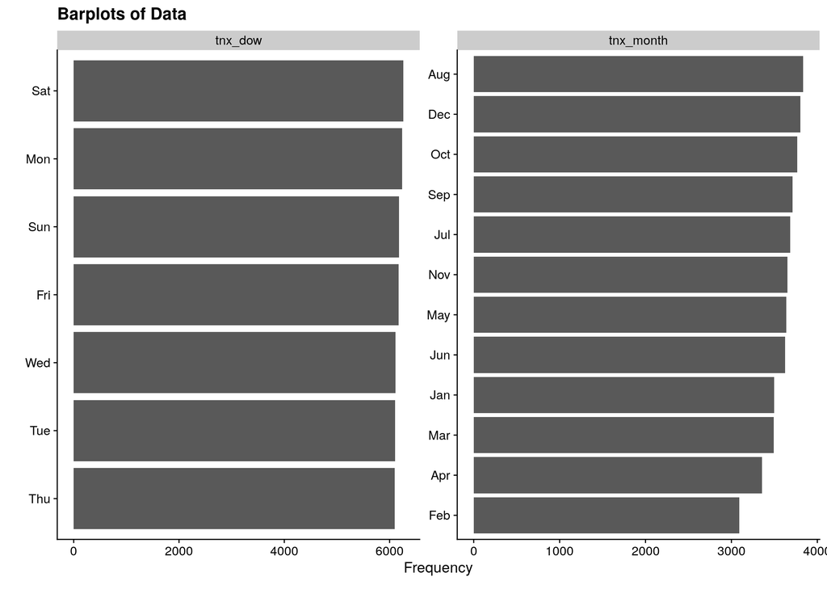

```r
plot_bar(
  data_tbl,
  ncol    = 2,
  nrow    = 2,
  title   = "Barplots of Data",
  ggtheme = theme_cowplot()
  )
```

We then have a quick look at histograms of the numeric variables.

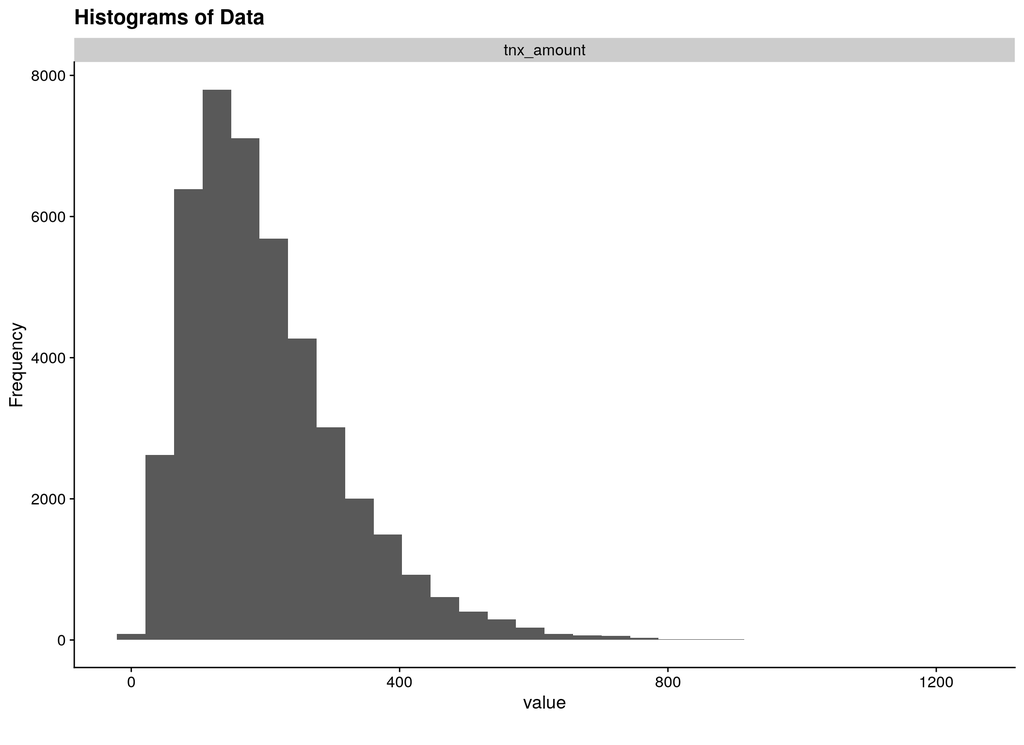

```r
plot_histogram(
  data_tbl,
  ncol    = 2,
  nrow    = 2,
  title   = "Histograms of Data",
  ggtheme = theme_cowplot()
  )
```

Finally, we split the remaining variables into different categories and then produce a sequence of plots for each variable.

```r
coltype_lst <- create_coltype_list(explore_data_tbl)

print(coltype_lst)
```

```
$split
$split$continuous
[1] "tnx_amount"

$split$datetime
[1] "tnx_timestamp"

$split$discrete
[1] "tnx_dow"   "tnx_month" "tnx_week"


$columns
tnx_timestamp       tnx_dow     tnx_month      tnx_week    tnx_amount
   "datetime"    "discrete"    "discrete"    "discrete"  "continuous"
```

## 4.2 Logical Variables

Logical variables only take two values: TRUE or FALSE. It is useful to see missing data as well though, so we also plot the count of those.

```r
logical_vars <- coltype_lst$split$logical |> sort()

for (plot_varname in logical_vars) {
  cat("--\n")
  cat(glue("{plot_varname}\n"))

  na_count <- explore_data_tbl |> pull(.data[[plot_varname]]) |> are_na() |> sum()

  plot_title <- glue("Barplot of Counts for Variable: {plot_varname} ({na_count} missing values)")

  explore_plot <- ggplot(explore_data_tbl) +
    geom_bar(aes(x = .data[[plot_varname]])) +
    xlab(plot_varname) +
    ylab("Count") +
    scale_y_continuous(labels = label_comma()) +
    ggtitle(plot_title) +
    theme(axis.text.x = element_text(angle = 30, vjust = 0.5))

  plot(explore_plot)
}
```

## 4.3 Numeric Variables

Numeric variables are usually continuous in nature, though we also have integer data.

```
--
tnx_amount   Min. 1st Qu.  Median    Mean 3rd Qu.    Max.
   7.51  115.29  176.08  200.49  258.48 1239.85
```

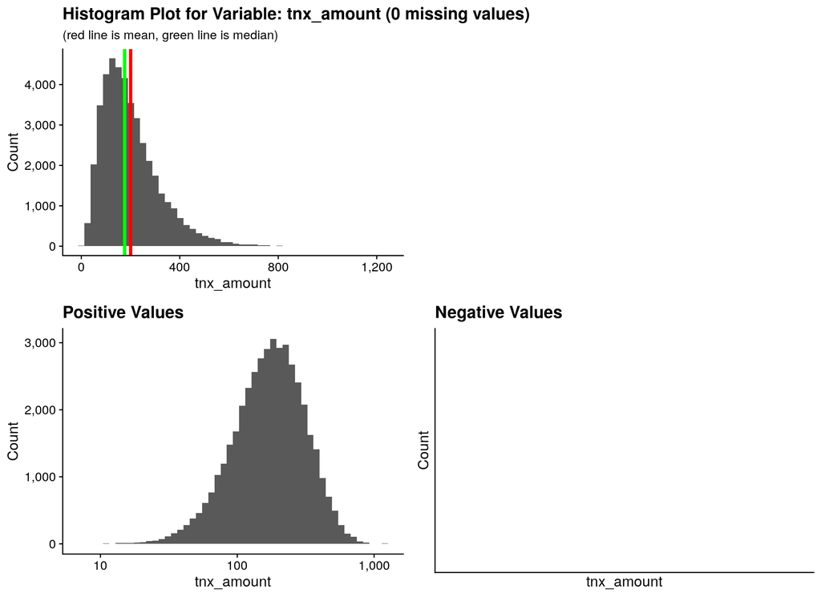

```r
numeric_vars <- coltype_lst$split$continuous |> sort()

for (plot_varname in numeric_vars) {
  cat("--\n")
  cat(glue("{plot_varname}\n"))

  plot_var <- explore_data_tbl |> pull(.data[[plot_varname]])
  na_count <- plot_var |> are_na() |> sum()

  plot_var |> summary() |> print()

  plot_title <- glue("Histogram Plot for Variable: {plot_varname} ({na_count} missing values)")


  all_plot <- ggplot() +
    geom_histogram(aes(x = plot_var), bins = dataexp_hist_bins_count) +
    geom_vline(xintercept = mean(plot_var, na.rm = TRUE),
               colour = "red", size = 1.5) +
    geom_vline(xintercept = median(plot_var, na.rm = TRUE),
               colour = "green", size = 1.5) +
    xlab(plot_varname) +
    ylab("Count") +
    scale_x_continuous(labels = label_comma()) +
    scale_y_continuous(labels = label_comma()) +
    ggtitle(
      plot_title,
      subtitle = "(red line is mean, green line is median)"
      )

  pos_data_tbl <- explore_data_tbl |>
    filter(.data[[plot_varname]] >= 0) |>
    mutate(var_val = abs(.data[[plot_varname]]))

  pos_log_plot <- ggplot(pos_data_tbl) +
    geom_histogram(aes(x = var_val), bins = dataexp_hist_bins_count) +
    xlab(plot_varname) +
    ylab("Count") +
    scale_x_log10(labels = label_comma()) +
    scale_y_continuous(labels = label_comma()) +
    ggtitle("Positive Values")


  neg_data_tbl <- explore_data_tbl |>
    filter(.data[[plot_varname]] < 0) |>
    mutate(var_val = abs(.data[[plot_varname]]))

  neg_log_plot <- ggplot(neg_data_tbl) +
    geom_histogram(aes(x = var_val), bins = dataexp_hist_bins_count) +
    xlab(plot_varname) +
    ylab("Count") +
    scale_x_log10(labels = label_comma()) +
    scale_y_continuous(labels = label_comma()) +
    ggtitle("Negative Values")


  plot_grid(
    all_plot,
    NULL,
    pos_log_plot,
    neg_log_plot,
    nrow = 2
    ) |>
    print()
}
```

## 4.4 Categorical Variables

Categorical variables only have values from a limited, and usually fixed, number of possible values

```
--
tnx_dow
```

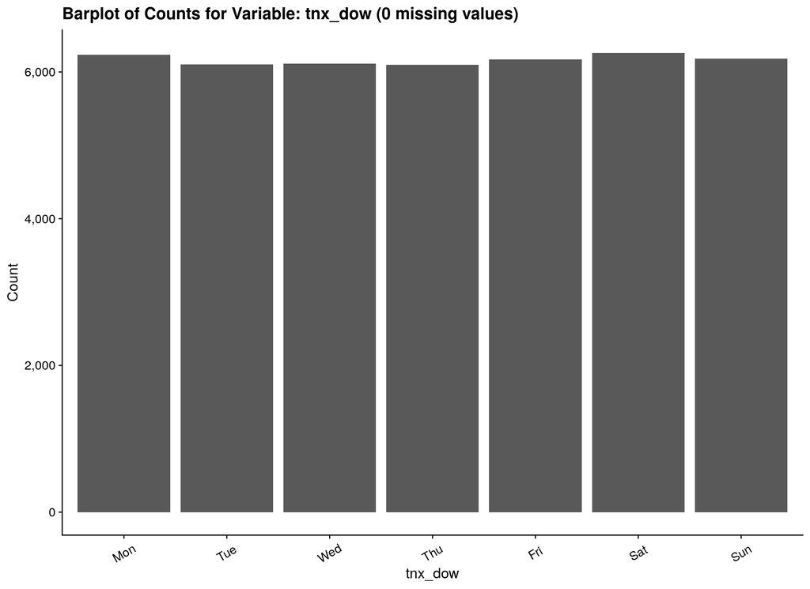

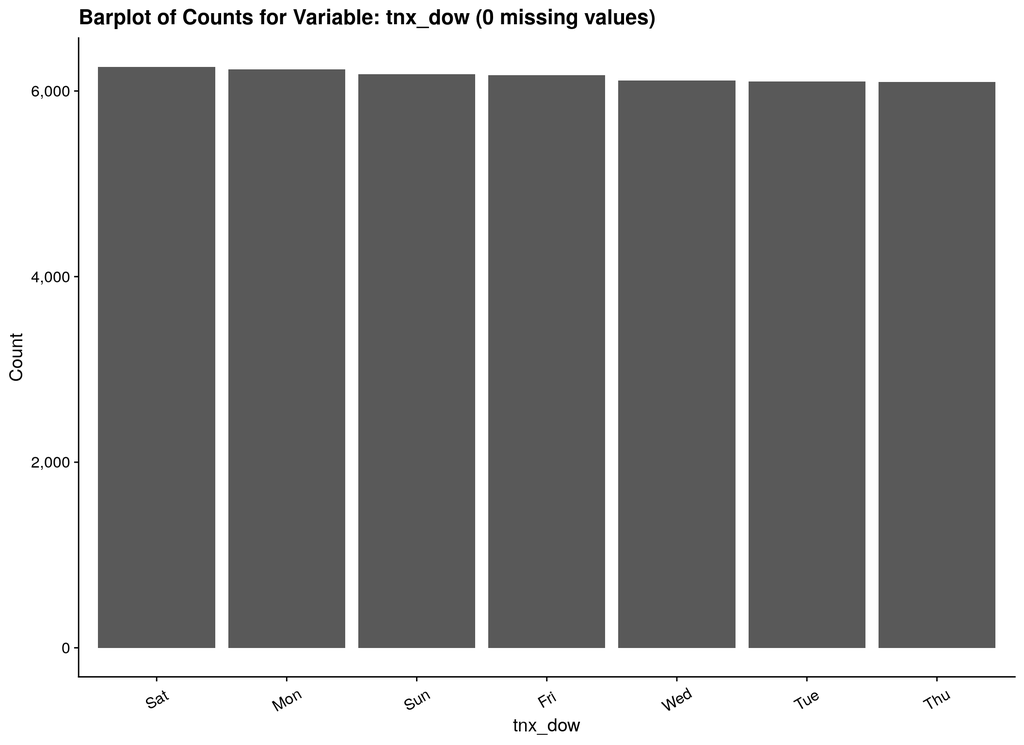

```
--
tnx_month
```

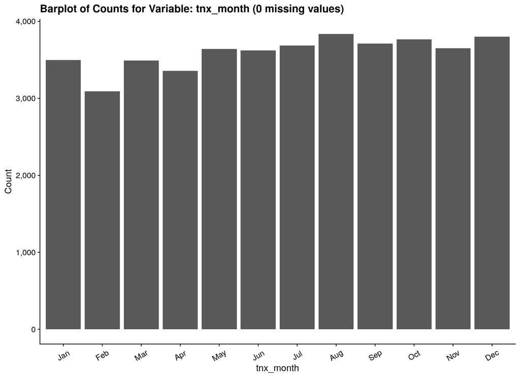

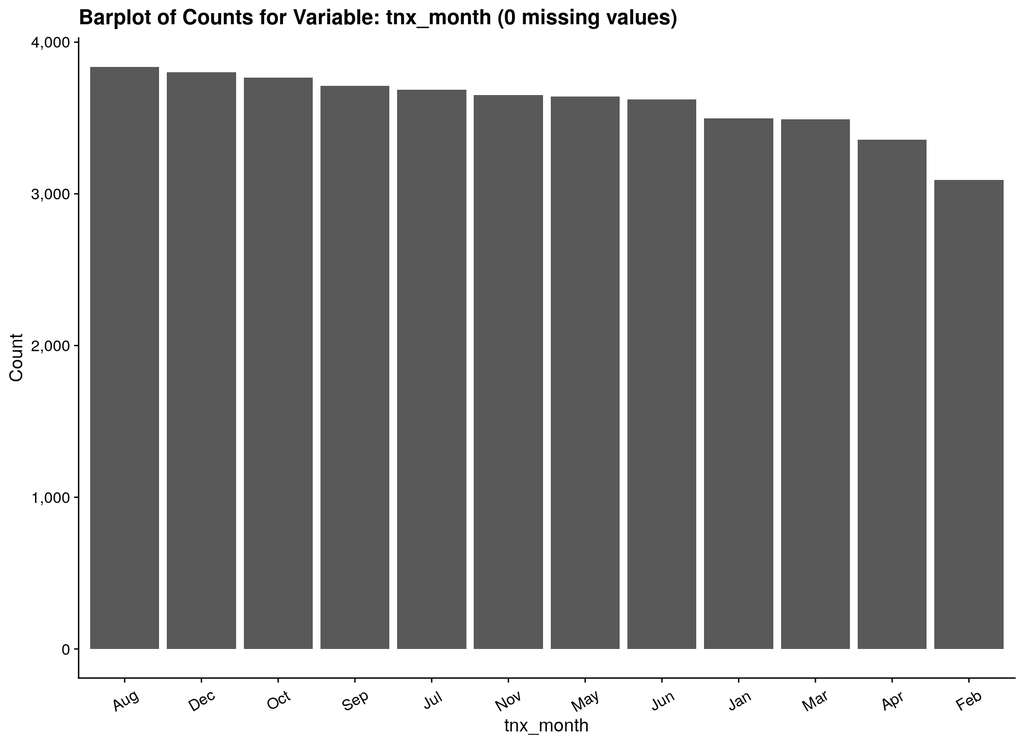

```
--
tnx_week
```

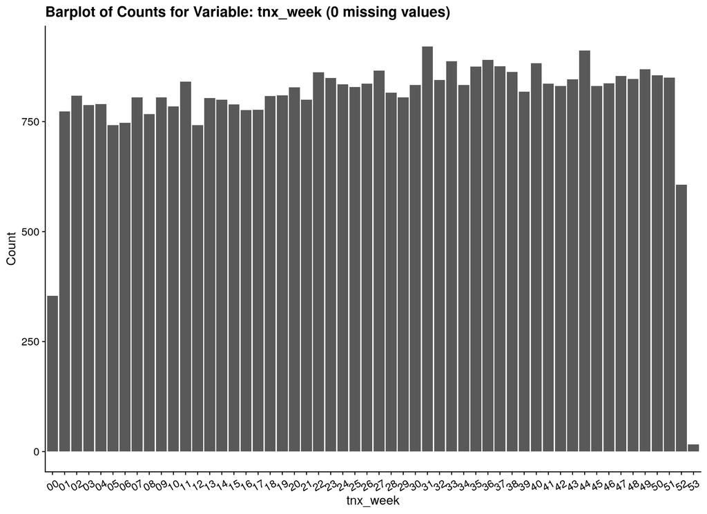

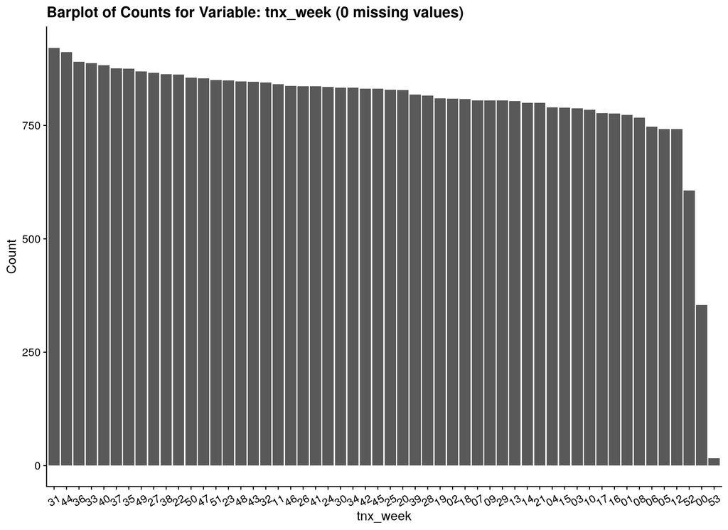

```r
categorical_vars <- coltype_lst$split$discrete |> sort()

for (plot_varname in categorical_vars) {
  cat("--\n")
  cat(glue("{plot_varname}\n"))

  na_count <- explore_data_tbl |> pull(.data[[plot_varname]]) |> are_na() |> sum()

  plot_title <- glue("Barplot of Counts for Variable: {plot_varname} ({na_count} missing values)")

  standard_plot_tbl <- explore_data_tbl |>
    count(.data[[plot_varname]])

  standard_plot <- ggplot(standard_plot_tbl) +
    geom_bar(aes(x = .data[[plot_varname]], weight = n)) +
    xlab(plot_varname) +
    ylab("Count") +
    scale_x_discrete(labels = ~ abbreviate(.x, minlength = 10)) +
    scale_y_continuous(labels = label_comma()) +
    ggtitle(plot_title) +
    theme(axis.text.x = element_text(angle = 30, vjust = 0.5))

  standard_plot |> print()


  desc_plot_tbl <- explore_data_tbl |>
    pull(.data[[plot_varname]]) |>
    fct_lump(n = dataexp_cat_level_count) |>
    fct_count() |>
    mutate(f = fct_relabel(f, str_trunc, width = 15))

  desc_plot <- ggplot(desc_plot_tbl) +
    geom_bar(aes(x = fct_reorder(f, -n), weight = n)) +
    xlab(plot_varname) +
    ylab("Count") +
    scale_x_discrete(labels = ~ abbreviate(.x, minlength = 10)) +
    scale_y_continuous(labels = label_comma()) +
    ggtitle(plot_title) +
    theme(axis.text.x = element_text(angle = 30, vjust = 0.5))

  desc_plot |> print()
}
```

## 4.5 Date/Time Variables

Date/Time variables represent calendar or time-based data should as time of the day, a date, or a timestamp.

```
--
tnx_timestamp                      Min.                    1st Qu.
"2010-01-01 04:21:16.3011" "2014-06-06 17:08:11.8218"
                    Median                       Mean
"2017-07-14 22:46:41.3844" "2017-04-12 06:59:54.7776"
                   3rd Qu.                       Max.
"2020-03-30 12:08:40.5470" "2022-12-31 23:30:33.6908"
```

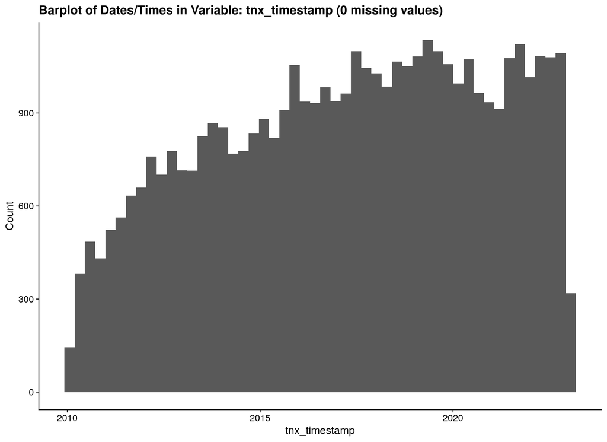

```r
datetime_vars <- coltype_lst$split$datetime |> sort()

for (plot_varname in datetime_vars) {
  cat("--\n")
  cat(glue("{plot_varname}\n"))

  plot_var <- explore_data_tbl |> pull(.data[[plot_varname]])
  na_count <- plot_var |> are_na() |> sum()

  plot_var |> summary() |> print()

  plot_title <- glue("Barplot of Dates/Times in Variable: {plot_varname} ({na_count} missing values)")


  explore_plot <- ggplot(explore_data_tbl) +
    geom_histogram(aes(x = .data[[plot_varname]]), bins = dataexp_hist_bins_count) +
    xlab(plot_varname) +
    ylab("Count") +
    scale_y_continuous(labels = label_comma()) +
    ggtitle(plot_title)

  plot(explore_plot)
}
```

# 5 Bivariate Facet Plots

We now move on to looking at bivariate plots of the data set.

A natural way to explore relationships in data is to create univariate visualisations facetted by a categorical value.

```r
### _TEMPLATE_
### facet_varname <- ''
facet_varname <- "tnx_month"

dataexp_facet_count_max <- 3
```

## 5.1 Logical Variables

For logical variables we facet on barplots of the levels, comparing TRUE, FALSE and missing data.

```r
logical_vars <- logical_vars[!logical_vars %in% facet_varname] |> sort()


for (plot_varname in logical_vars) {
  cat("--\n")
  cat(plot_varname)

  plot_tbl <- data_tbl |> filter(!are_na(.data[[plot_varname]]))

  explore_plot <- ggplot(plot_tbl) +
    geom_bar(aes(x = .data[[plot_varname]])) +
    facet_wrap(facet_varname, scales = "free") +
    xlab(plot_varname) +
    ylab("Count") +
    scale_y_continuous(labels = label_comma()) +
    ggtitle(glue("{facet_varname}-Faceted Histogram for Variable: {plot_varname}")) +
    theme(axis.text.x = element_text(angle = 30, vjust = 0.5))

  plot(explore_plot)
}
```

## 5.2 Numeric Variables

For numeric variables, we facet on histograms of the data.

```
--
tnx_amount
```

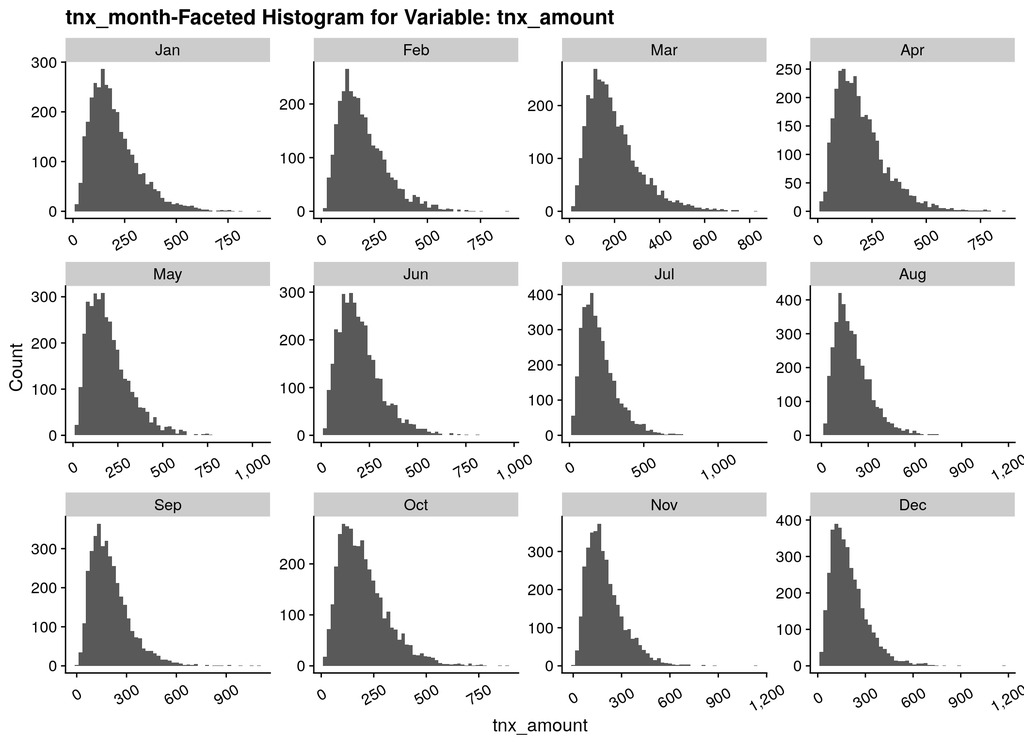

```r
for (plot_varname in numeric_vars) {
  cat("--\n")
  cat(plot_varname)

  plot_tbl <- data_tbl |> filter(!are_na(.data[[plot_varname]]))

  explore_plot <- ggplot(plot_tbl) +
    geom_histogram(aes(x = .data[[plot_varname]]), bins = dataexp_hist_bins_count) +
    facet_wrap(facet_varname, scales = "free") +
    xlab(plot_varname) +
    ylab("Count") +
    scale_x_continuous(labels = label_comma()) +
    scale_y_continuous(labels = label_comma()) +
    ggtitle(glue("{facet_varname}-Faceted Histogram for Variable: {plot_varname}")) +
    theme(axis.text.x = element_text(angle = 30, vjust = 0.5))

  print(explore_plot)
}
```

## 5.3 Categorical Variables

We treat categorical variables like logical variables, faceting the barplots of the different levels of the data.

```
--
tnx_dow
```

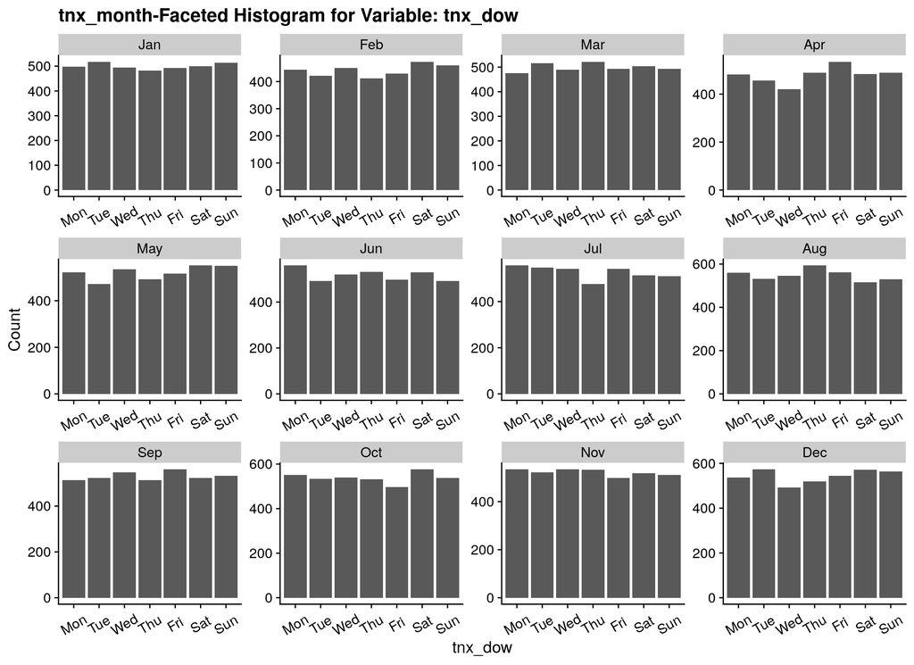

```
--
tnx_week
```

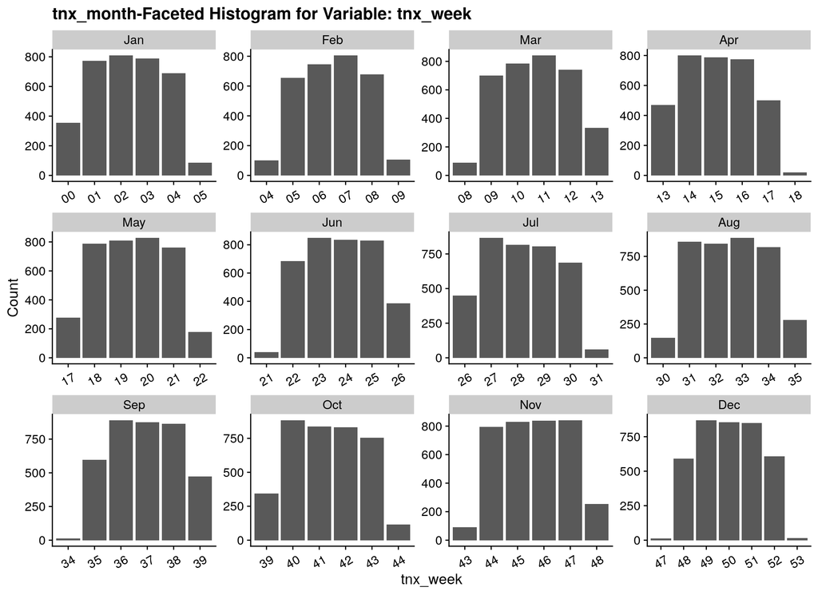

```r
categorical_vars <- categorical_vars[!categorical_vars %in% facet_varname] |> sort()

for (plot_varname in categorical_vars) {
  cat("--\n")
  cat(plot_varname)

  plot_tbl <- data_tbl |>
    filter(!are_na(.data[[plot_varname]])) |>
    mutate(
      varname_trunc = fct_relabel(.data[[plot_varname]], str_trunc, width = 10)
      )

  explore_plot <- ggplot(plot_tbl) +
    geom_bar(aes(x = varname_trunc)) +
    facet_wrap(facet_varname, scales = "free") +
    xlab(plot_varname) +
    ylab("Count") +
    scale_x_discrete(labels = ~ abbreviate(.x, minlength = 10)) +
    scale_y_continuous(labels = label_comma()) +
    ggtitle(glue("{facet_varname}-Faceted Histogram for Variable: {plot_varname}")) +
    theme(axis.text.x = element_text(angle = 30, vjust = 0.5))

  plot(explore_plot)
}
```

## 5.4 Date/Time Variables

Like the univariate plots, we facet on histograms of the years in the dates.

```
--
tnx_timestamp
```

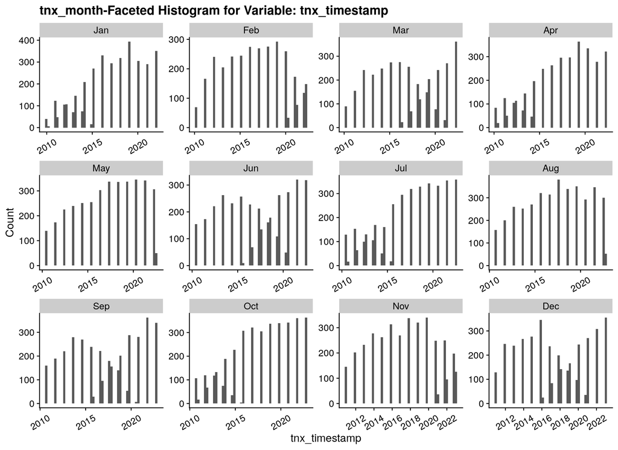

```r
for (plot_varname in datetime_vars) {
  cat("--\n")
  cat(plot_varname)

  plot_tbl <- data_tbl |> filter(!are_na(.data[[plot_varname]]))

  explore_plot <- ggplot(plot_tbl) +
    geom_histogram(aes(x = .data[[plot_varname]]), bins = dataexp_hist_bins_count) +
    facet_wrap(facet_varname, scales = "free") +
    xlab(plot_varname) +
    ylab("Count") +
    scale_y_continuous(labels = label_comma()) +
    ggtitle(glue("{facet_varname}-Faceted Histogram for Variable: {plot_varname}")) +
    theme(axis.text.x = element_text(angle = 30, vjust = 0.5))

  plot(explore_plot)
}
```

# 6 Custom Explorations

In this section we perform various data explorations.

We now want to construct some customer cohort data.

```r
customer_cohort_data_tbl <- data_tbl |>
  group_by(customer_id) |>
  summarise(
    .groups = "drop",

    first_tnx_date = min(tnx_timestamp),
    total_tnx_count = n(),
    ) |>
  mutate(
    cohort_qtr = first_tnx_date |> zoo::as.yearqtr() |> as.character(),
    cohort_ym  = first_tnx_date |> format("%Y %m"),

    .after = customer_id
    )

customer_cohort_data_tbl |> glimpse()
```

```
Rows: 5,000
Columns: 5
$ customer_id     <chr> "LFC201001_0001", "LFC201001_0002", "LFC201001_0003", …
$ cohort_qtr      <chr> "2010 Q1", "2010 Q1", "2010 Q1", "2010 Q1", "2010 Q1",…
$ cohort_ym       <chr> "2010 01", "2010 01", "2010 01", "2010 01", "2010 01",…
$ first_tnx_date  <dttm> 2010-01-01 04:21:16, 2010-01-03 11:37:28, 2010-01-03 …
$ total_tnx_count <int> 3, 2, 9, 1, 4, 5, 80, 2, 3, 4, 16, 11, 22, 1, 2, 8, 4,…
```

# 7 Construct BTYD Datasets

We start by modelling the P/NBD model using our synthetic datasets before we try to model real-life data.

```r
use_fit_start_date <- as.Date("2010-01-01")
use_fit_end_date   <- as.Date("2022-01-01")

use_valid_start_date <- as.Date("2022-01-01")
use_valid_end_date   <- as.Date("2023-01-01")
```

```r
customer_transactions_tbl <- data_tbl |>
  mutate(
    orig_id     = customer_id,
    customer_id = fct_reorder(customer_id, tnx_timestamp, min)
    )

customer_transactions_tbl |> glimpse()
```

```
Rows: 43,153
Columns: 8
$ customer_id   <fct> LFC201001_0001, LFC201001_0003, LFC201001_0002, LFC20100…
$ tnx_timestamp <dttm> 2010-01-01 04:21:16, 2010-01-03 09:17:44, 2010-01-03 11…
$ tnx_dow       <fct> Fri, Sun, Sun, Tue, Wed, Wed, Fri, Sat, Sun, Mon, Tue, T…
$ tnx_month     <fct> Jan, Jan, Jan, Jan, Jan, Jan, Jan, Jan, Jan, Jan, Jan, J…
$ tnx_week      <chr> "00", "00", "00", "01", "01", "01", "01", "01", "01", "0…
$ invoice_id    <chr> "T20100101-0001", "T20100103-0001", "T20100103-0002", "T…
$ tnx_amount    <dbl> 82.97, 174.89, 126.14, 121.05, 99.23, 238.19, 54.69, 116…
$ orig_id       <chr> "LFC201001_0001", "LFC201001_0003", "LFC201001_0002", "L…
```

## 7.1 Construct Datasets

Having loaded the synthetic data we need to construct a number of datasets of derived values.

```r
customer_summarystats_tbl <- customer_transactions_tbl |>
  drop_na(customer_id) |>
  calculate_transaction_cbs_data(last_date = use_fit_end_date |> as.POSIXct())

customer_summarystats_tbl |> glimpse()
```

```
Rows: 4,604
Columns: 6
$ customer_id    <fct> LFC201001_0001, LFC201001_0003, LFC201001_0002, LFC2010…
$ first_tnx_date <dttm> 2010-01-01 04:21:16, 2010-01-03 09:17:44, 2010-01-03 1…
$ last_tnx_date  <dttm> 2010-02-08 23:59:04, 2010-07-17 16:36:08, 2010-02-04 0…
$ x              <dbl> 2, 8, 1, 0, 4, 3, 79, 1, 2, 3, 15, 10, 21, 7, 0, 1, 0, …
$ t_x            <dbl> 5.5454169, 27.9006351, 4.5257018, 0.0000000, 5.4047249,…
$ T_cal          <dbl> 626.1169, 625.8018, 625.7879, 625.4928, 625.3704, 625.3…
```

As before, we construct a number of subsets of the data for use later on with the modelling and create some data subsets.

```r
shuffle_tbl <- customer_summarystats_tbl |>
  slice_sample(prop = 1, replace = FALSE)

id_50    <- shuffle_tbl |> head(50)    |> pull(customer_id) |> sort()
id_1000  <- shuffle_tbl |> head(1000)  |> pull(customer_id) |> sort()
```

```r
customer_fit_stats_tbl <- customer_summarystats_tbl
customer_fit_stats_tbl |> glimpse()
```

```
Rows: 4,604
Columns: 6
$ customer_id    <fct> LFC201001_0001, LFC201001_0003, LFC201001_0002, LFC2010…
$ first_tnx_date <dttm> 2010-01-01 04:21:16, 2010-01-03 09:17:44, 2010-01-03 1…
$ last_tnx_date  <dttm> 2010-02-08 23:59:04, 2010-07-17 16:36:08, 2010-02-04 0…
$ x              <dbl> 2, 8, 1, 0, 4, 3, 79, 1, 2, 3, 15, 10, 21, 7, 0, 1, 0, …
$ t_x            <dbl> 5.5454169, 27.9006351, 4.5257018, 0.0000000, 5.4047249,…
$ T_cal          <dbl> 626.1169, 625.8018, 625.7879, 625.4928, 625.3704, 625.3…
```

```r
customer_valid_stats_tbl <- customer_transactions_tbl |>
  semi_join(customer_fit_stats_tbl, by = "customer_id") |>
  filter(
    tnx_timestamp > (use_valid_start_date |> as.POSIXct())
    ) |>
  summarise(
    tnx_count = n(),
    tnx_last_interval = difftime(
        max(tnx_timestamp),
        use_valid_start_date,
        units = "weeks"
        ) |>
      as.numeric(),

    .by = customer_id
    )

customer_valid_stats_tbl |> glimpse()
```

```
Rows: 237
Columns: 3
$ customer_id       <fct> LFC202004_0021, LFC202101_0033, LFC202106_0004, LFC2…
$ tnx_count         <int> 38, 13, 5, 23, 9, 13, 1, 1, 6, 12, 17, 56, 25, 20, 6…
$ tnx_last_interval <dbl> 39.6614305, 46.7777234, 25.8559689, 43.6519743, 28.8…
```

```r
obs_fitdata_tbl <- customer_fit_stats_tbl |>
  rename(tnx_count = x)


### We need to add all the zero count customers into the valid data
obs_validdata_tbl <- customer_fit_stats_tbl |>
  anti_join(customer_valid_stats_tbl, by = "customer_id") |>
  transmute(customer_id, tnx_count = 0) |>
  bind_rows(customer_valid_stats_tbl) |>
  arrange(customer_id)
```

Finally, we want to ensure there is a proper lookup table for the original (non-factor) `customer_id` and the one that is a factor.

```r
customer_id_lookup_tbl <- customer_transactions_tbl |>
  select(customer_id, orig_id) |>
  distinct()

customer_id_lookup_tbl |> glimpse()
```

```
Rows: 5,000
Columns: 2
$ customer_id <fct> LFC201001_0001, LFC201001_0003, LFC201001_0002, LFC201001_…
$ orig_id     <chr> "LFC201001_0001", "LFC201001_0003", "LFC201001_0002", "LFC…
```

# 8 Output Cleaned Data

Finally we output the various datasets we have constructed to disks.

```r
id_1000  |> write_rds("data/longsynth_customer_subset_ids.rds")

customer_summarystats_tbl |> write_rds("data/longsynth_customer_summarystats_tbl.rds")

customer_cohort_data_tbl |>
  write_rds("data/longsynth_customer_cohort_data_tbl.rds")

customer_fit_stats_tbl |>
  write_rds("data/longsynth_customer_fit_stats_tbl.rds")

customer_valid_stats_tbl |>
  write_rds("data/longsynth_customer_valid_stats_tbl.rds")

customer_transactions_tbl |>
  write_rds("data/longsynth_transaction_data_tbl.rds")

obs_fitdata_tbl   |> write_rds("data/longsynth_obs_fitdata_tbl.rds")
obs_validdata_tbl |> write_rds("data/longsynth_obs_validdata_tbl.rds")

list(
    use_fit_start_date = use_fit_start_date,
    use_fit_end_date   = use_fit_end_date,

    use_valid_start_date = use_valid_start_date,
    use_valid_end_date   = use_valid_end_date
    ) |>
  write_rds("data/longsynth_simulation_dates.rds")

customer_id_lookup_tbl |>
  write_rds("data/longsynth_customer_id_lookup_tbl.rds")
```